# Lab 4

Mikaela Blount and Jaden Birkner

10/24/2019

#### Owner’s GitHub username: jebirkner

#### Partner’s GitHub username: mblount2

#### Repo name: ds202_lab4

#### Due date: Thursday Oct. 24 by 10 pm.

## Part one: Cleaning data

```r
library(tidyverse)
library(readxl)
defense <- read_excel('cyclonesFootball2018.xlsx', sheet='Defensive')
str(defense)
```

```
## Classes 'tbl_df', 'tbl' and 'data.frame':    446 obs. of  11 variables:
##  $ Name             : chr  "Eisworth, Greg" "Eisworth, Greg" "Eisworth, Greg" "Eisworth, Greg" ...
##  $ Opponent_Opponent: chr  "Iowa" "Oklahoma" "Akron" "TCU" ...
##  $ Tackles_Solo     : chr  "3" "6" "7" "6" ...
##  $ Tackles_ASST     : chr  "3" "8" "2" "3" ...
##  $ Tackles_TFL      : chr  "0" "1.0" "1.0" "0" ...
##  $ Tackles_Sack     : chr  "0" "0" "0" "0" ...
##  $ Turnover_FF      : chr  "0" "1" "0" "0" ...
##  $ Turnover_FR      : chr  "0" "0" "0" "0" ...
##  $ Turnover_INT     : chr  "0" "0" "0" "0" ...
##  $ Pass_QBH         : chr  "0" "0" "0" "0" ...
##  $ Pass_PB          : chr  "0" "0" "3" "0" ...
```

```r
offense <- read_excel('cyclonesFootball2018.xlsx', sheet='Offensive')
bio <- read_excel('cyclonesFootball2018.xlsx', sheet='Biography')
```

```r
defense$Name = factor(defense$Name)
defense$Opponent_Opponent = factor(defense$Opponent_Opponent)
offense$Name = factor(offense$Name)
offense$Opponent_Opponent = factor(offense$Opponent_Opponent)
bio$Name = factor(bio$Name)
```

```r
defClean = mutate_at(defense, , .funs = as.numeric, .vars = c("Tackles_Solo", "Tackles_ASST","Tackles_TFL", "Tackles_Sack", "Turnover_FF", "Turnover_FR", "Turnover_INT", "Pass_QBH", "Pass_PB"))
```

```r
offClean = mutate_at(offense, .funs = as.numeric, .vars = names(offense[c(3:12)]))
bio = mutate_at(bio, .funs = as.numeric, .vars = c("Weight"))
```

```r
bioClean = bio %>%
  separate(Height, into = c("Feet", "Inches"))
bioClean$Feet = as.numeric(bioClean$Feet)
bioClean$Inches = as.numeric(bioClean$Inches)
bioClean$Feet = bioClean$Feet * 12
bioClean = mutate(bioClean, Height = bioClean$Feet + bioClean$Inches)
bioClean = select(bioClean, "Name", "Position", "Weight", "Class",  "Hometown", "Highschool", "Height")
names(bioClean)
```

```
## [1] "Name"       "Position"   "Weight"     "Class"      "Hometown"
## [6] "Highschool" "Height"
```

```r
(str(defClean))
```

```
## Classes 'tbl_df', 'tbl' and 'data.frame':    446 obs. of  11 variables:
##  $ Name             : Factor w/ 42 levels "Akers, Landen",..: 7 7 7 7 7 7 7 7 7 7 ...
##  $ Opponent_Opponent: Factor w/ 13 levels "Akron","Baylor",..: 4 7 1 9 8 13 11 5 2 10 ...
##  $ Tackles_Solo     : num  3 6 7 6 3 5 3 7 2 9 ...
##  $ Tackles_ASST     : num  3 8 2 3 0 3 2 1 4 3 ...
##  $ Tackles_TFL      : num  0 1 1 0 1 1 0 0 0 0 ...
##  $ Tackles_Sack     : num  0 0 0 0 0 1 0 0 0 0 ...
##  $ Turnover_FF      : num  0 1 0 0 0 0 0 0 0 1 ...
##  $ Turnover_FR      : num  0 0 0 0 0 0 0 0 0 0 ...
##  $ Turnover_INT     : num  0 0 0 0 0 0 1 0 0 0 ...
##  $ Pass_QBH         : num  0 0 0 0 0 0 0 0 0 0 ...
##  $ Pass_PB          : num  0 0 3 0 0 0 0 0 0 0 ...
```

```r
(str(offClean))
```

```
## Classes 'tbl_df', 'tbl' and 'data.frame':    168 obs. of  12 variables:
##  $ Name             : Factor w/ 15 levels "Akers, Landen",..: 6 6 6 6 6 6 6 6 6 6 ...
##  $ Opponent_Opponent: Factor w/ 13 levels "Akron","Baylor",..: 4 7 1 9 8 13 11 5 2 10 ...
##  $ Receiving_REC    : num  1 9 6 3 6 1 1 4 4 0 ...
##  $ Receiving_YDS    : num  31 66 39 23 37 32 4 31 39 0 ...
##  $ Receiving_TD     : num  0 0 0 0 1 1 0 0 1 0 ...
##  $ Rushing_ATT      : num  NA NA NA NA NA NA NA NA NA NA ...
##  $ Rushing_YDS      : num  NA NA NA NA NA NA NA NA NA NA ...
##  $ Rushing_TD       : num  NA NA NA NA NA NA NA NA NA NA ...
##  $ Passing_CMP-ATT  : num  NA NA NA NA NA NA NA NA NA NA ...
##  $ Passing_YDS      : num  NA NA NA NA NA NA NA NA NA NA ...
##  $ Passing_TD       : num  NA NA NA NA NA NA NA NA NA NA ...
##  $ Passing_INT      : num  NA NA NA NA NA NA NA NA NA NA ...
```

```r
(str(bioClean))
```

```
## Classes 'tbl_df', 'tbl' and 'data.frame':    123 obs. of  7 variables:
##  $ Name      : Factor w/ 123 levels "Akers, Landen",..: 1 2 3 4 5 6 7 8 9 10 ...
##  $ Position  : chr  "Wide Receiver" "Tight End" "Offensive Line" "Tight End" ...
##  $ Weight    : num  192 240 290 250 191 205 192 224 251 284 ...
##  $ Class     : chr  "Redshirt Sophomore" "Redshirt Sophomore" "Redshirt Freshman" "Redshirt Senior" ...
##  $ Hometown  : chr  "Cedar Rapids, Iowa" "Nixa, Mo." "Cedar Rapids, Iowa" "League City, Texas" ...
##  $ Highschool: chr  "Washington" "Nixa" "Washington" "Clear Falls" ...
##  $ Height    : num  72 79 74 76 72 71 72 75 74 74 ...
```

## Part two: Tidying (A)

```r
defClean2 = defClean %>%
  gather(key = "Statistic", value = "Value",Tackles_Solo, Tackles_ASST, Tackles_TFL, Tackles_Sack, Turnover_FF, Turnover_FR, Turnover_INT, Pass_QBH, Pass_PB)
```

2. The rarest defensive skill is creating turnovers, espically interceptions (Turnover_INT). This makes sense because the big 12 is known for terrible defensives and high-power offenses; University of Oklahoma’s last two quarterbacks were Heisman Winners. Iowa State also struggled for many years with talent on defensive until Matt Campell’s second year.

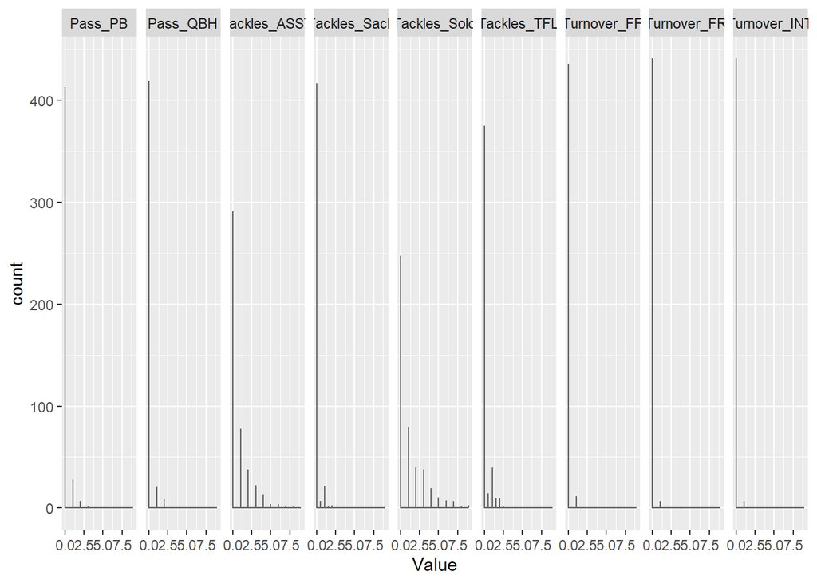

```r
ggplot(defClean2, aes(x=Value)) +
    geom_histogram(position="identity", colour="grey40", bins = 10000) +
    facet_grid(. ~ Statistic)
```

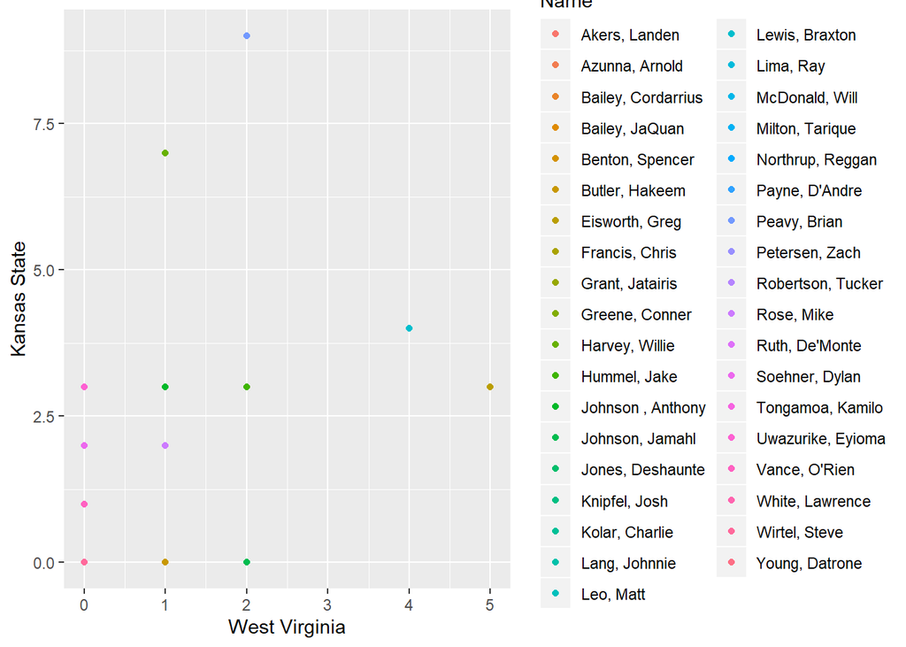

```r
defKSWV = defClean2 %>%
  filter(Statistic == "Tackles_Solo" & Opponent_Opponent %in% c("West Virginia","Kansas State")) %>%
  spread(key = Statistic, value = Value)

d = defKSWV %>%
  spread(key = Opponent_Opponent,value = Tackles_Solo)

ggplot(d ,aes(y = `Kansas State`, x = `West Virginia`,color=Name)) + geom_point(na.rm = TRUE)
```

## Part two: Tidying (B)

Now let’s turn our attention to the player biography `bioClean`.

```r
bioClean2 = bioClean %>%
  separate(Hometown, c("City","State"), sep = ", ", remove = TRUE)

head(bioClean2)
```

```
## # A tibble: 6 x 8
##   Name       Position    Weight Class       City    State Highschool Height
##   <fct>      <chr>        <dbl> <chr>       <chr>   <chr> <chr>       <dbl>
## 1 Akers, La~ Wide Recei~    192 Redshirt S~ Cedar ~ Iowa  Washington     72
## 2 Allen, Ch~ Tight End      240 Redshirt S~ Nixa    Mo.   Nixa           79
## 3 Alt, Gerry Offensive ~    290 Redshirt F~ Cedar ~ Iowa  Washington     74
## 4 Anderson,~ Tight End      250 Redshirt S~ League~ Texas Clear Fal~     76
## 5 Assalley,~ Placekicker    191 Redshirt S~ Naperv~ Ill.  Central        72
## 6 Austin, A~ Linebacker     205 Redshirt S~ Walnut  Cali~ Bishop Am~     71
```

```r
table(bioClean2$State)
```

```
##
##     Ariz.      Ark. Australia    Calif.      D.C.      Fla.       Ga.
##         3         2         2         8         1         8         2
##      Ill.      Iowa      Kan.     Mass.       Md.     Mich.     Minn.
##         5        44         3         1         1         5         2
##     Miss.       Mo.      Neb.   Nigeria      Ohio     Okla.       Pa.
##         1         1         1         1        10         4         2
##      S.C.     Texas       Va.      Wis.
##         2         9         1         4
```

## Part three: Joining data frames

```r
offbio = left_join(offClean, bioClean, by = "Name")
offbio %>% select("Name", "Hometown") %>% unique()
```

```
## # A tibble: 15 x 2
##    Name              Hometown
##    <chr>             <chr>
##  1 Jones, Deshaunte  Cincinnati, Ohio
##  2 Milton, Tarique   Bradenton, Fla.
##  3 Butler, Hakeem    Baltimore, Md.
##  4 Lang, Johnnie     Palmetto, Fla.
##  5 Akers, Landen     Cedar Rapids, Iowa
##  6 Kolar, Charlie    Norman, Okla.
##  7 Montgomery, David Cincinnati, Ohio
##  8 Purdy, Brock      Gilbert, Ariz.
##  9 Nwangwu, Kene     Frisco, Texas
## 10 Noland, Zeb       <NA>
## 11 Kempt, Kyle       Massillon, Ohio
## 12 Eaton, Matthew    Norfolk, Va.
## 13 Allen, Chase      Nixa, Mo.
## 14 Seonbuchner, Sam  Oconomowoc, Wis.
## 15 Johnson, Josh     Little Rock, Ark.
```

This is a list of all the offensive players and where they are from.

```r
df1 = inner_join(offClean, bioClean, by = "Name")
```

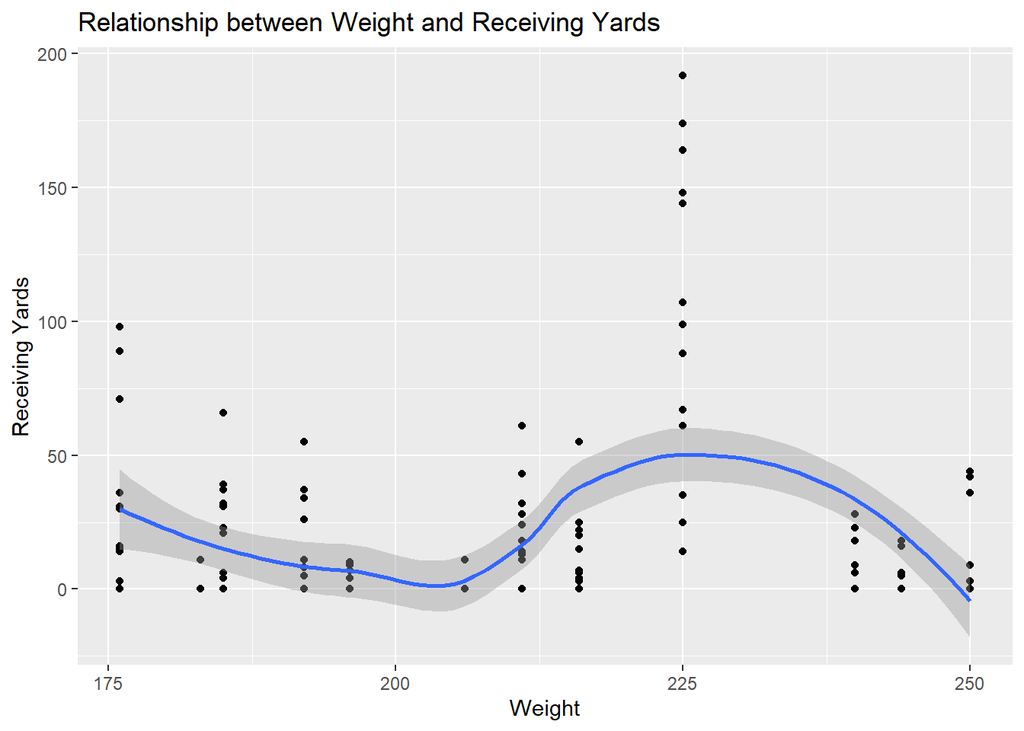

```r
ggplot(df1, aes(x = `Weight`, y = `Receiving_YDS`)) + geom_point() + labs(title = "Relationship between Weight and Receiving Yards", x='Weight', y='Receiving Yards') + geom_smooth()
```

Based on this graph there is no correlation between weight and receiving yards.

Question: Is there a correlation between Height and solo tackles.

```r
def_bio = inner_join(defClean, bioClean, by = "Name")
```

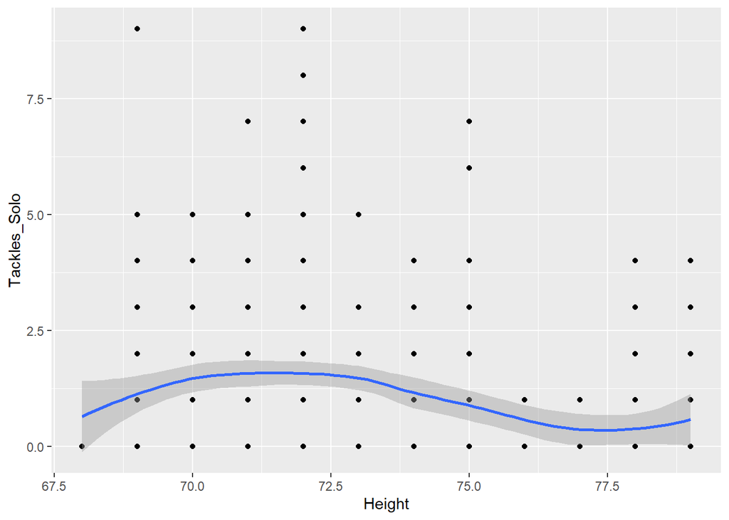

```r
ggplot(def_bio, aes(x = `Height`, y = `Tackles_Solo`)) + geom_point() + geom_smooth()
```

Answer: Based on the scattler plot above, there is no meaningful correlation between number of solo tackles and player Height.